# Analiza podataka blockchain trgovačkog lanca primjenom Apache Spark i mašinskog učenja

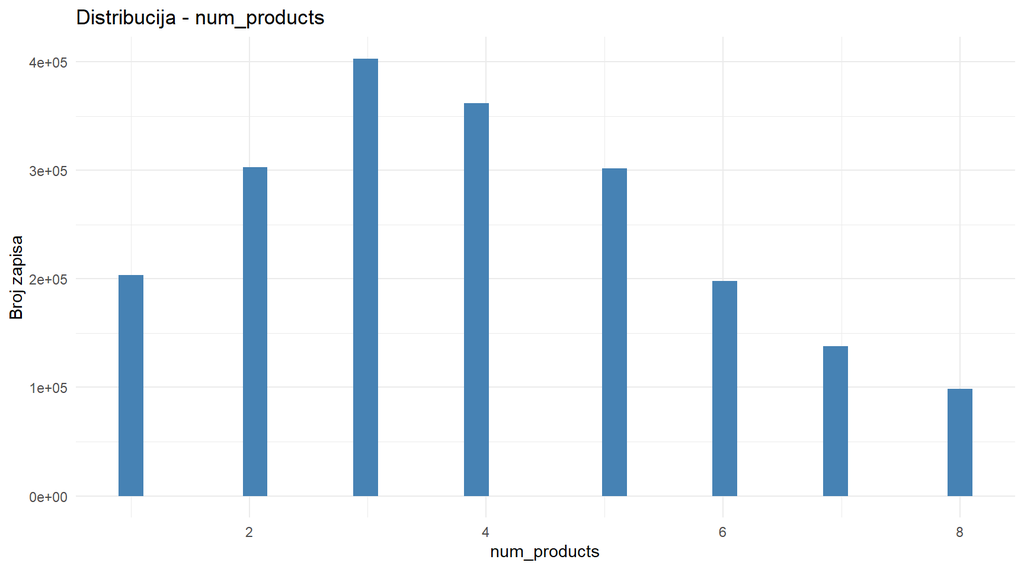

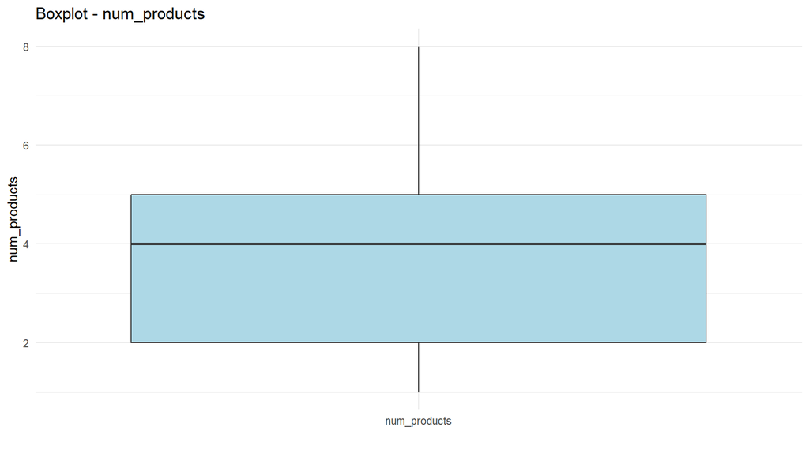

```
##       Metrics    Value
## 1         Min 1.000000
## 2         Max 8.000000
## 3     Average 3.943554
## 4     Std_Dev 1.913670
## 5      Median 4.000000
## 6 Quantile_25 2.000000
## 7 Quantile_75 5.000000
## Name:  total_cost     Type:  DoubleType
```

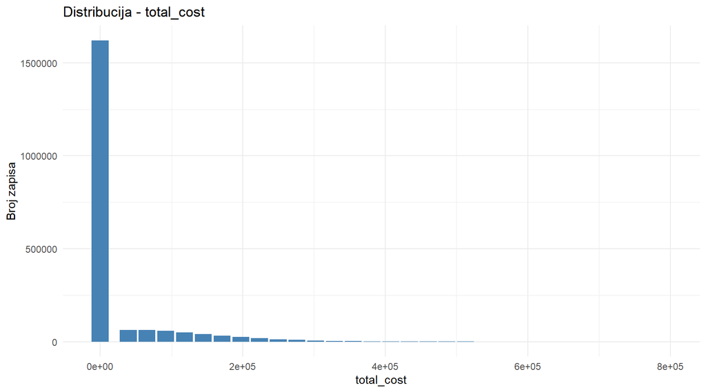

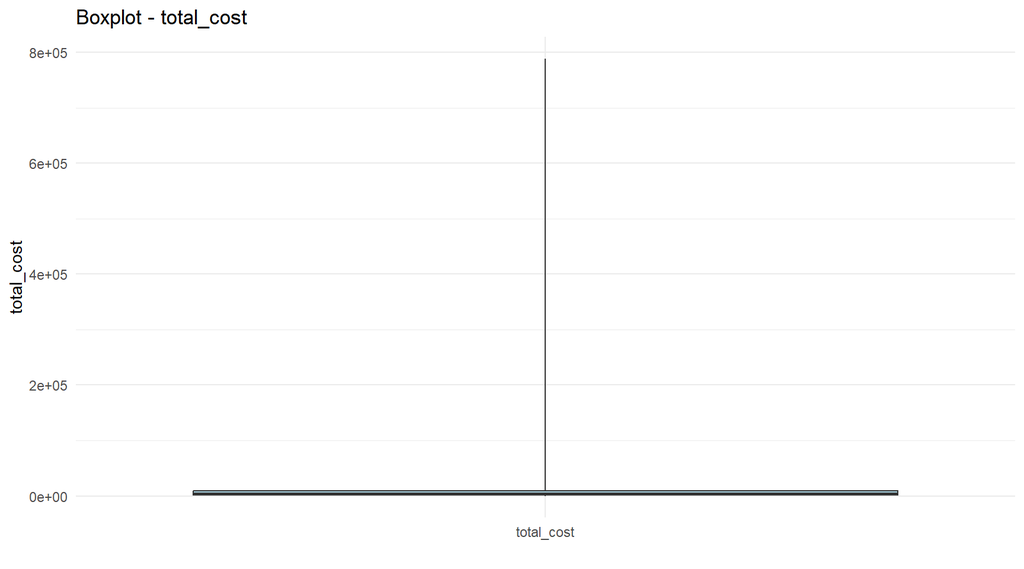

```
##       Metrics     Value
## 1         Min     30.00
## 2         Max 788822.64
## 3     Average  27576.96
## 4     Std_Dev  60258.91
## 5      Median   3348.39
## 6 Quantile_25   1566.44
## 7 Quantile_75   8816.87
## Name:  deleted    Type:  BooleanType
```

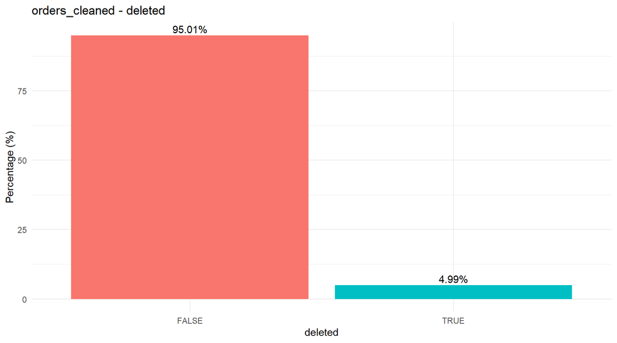

```
## # A tibble: 2 × 3
##   Value Frequency   Pct
##   <lgl>     <dbl> <dbl>
## 1 TRUE     100241  4.99
## 2 FALSE   1907308 95.0
```

```r
analyze_and_visualize(receipts_cleaned)
```

```
## Name:  doc_type   Type:  StringType
## # A tibble: 1 × 3
##   Value   Frequency Pct_Of_Total
##   <chr>       <dbl>        <dbl>
## 1 receipt   1878385          100
```

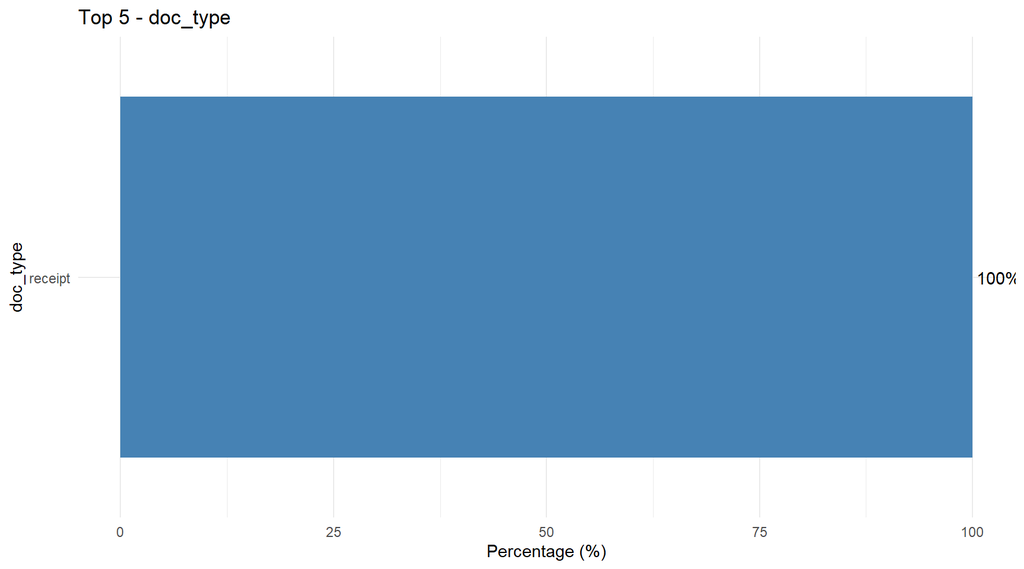

```
## Name:  id     Type:  StringType
## # A tibble: 5 × 3
##   Value                                Frequency Pct_Of_Total
##   <chr>                                    <dbl>        <dbl>
## 1 29bccb69-8630-4be5-849f-9a543dbe77c9         1            0
## 2 01c0f160-065d-40dc-b37d-3d8bc65ed956         1            0
## 3 77415032-36a2-4b95-a5a0-fd8eb553a931         1            0
## 4 07923181-ceff-4fc0-910f-2e14a83847cc         1            0
## 5 9fa562dd-4aed-40f2-a1c8-abff11ae0470         1            0
## # A tibble: 0 × 2
## # ℹ 2 variables: id <chr>, Count <dbl>
## Name:  trader_id      Type:  StringType
## # A tibble: 5 × 3
##   Value                                Frequency Pct_Of_Total
##   <chr>                                    <dbl>        <dbl>
## 1 f658815b-c008-4d59-9165-b40353ce8cc0        56            0
## 2 3a4e88a3-193c-4c0e-8bf1-f4451a73505e        51            0
## 3 5b9721e9-6930-4a6b-be34-4c0c7f91beba        50            0
## 4 3c191dc2-cb83-4486-8ecc-ed0a4ad2e358        50            0
## 5 57869379-4da3-4bfc-8008-608ff5d1f984        50            0
## # A tibble: 5 × 2
##   trader_id                            Count
##   <chr>                                <dbl>
## 1 f658815b-c008-4d59-9165-b40353ce8cc0    56
## 2 3a4e88a3-193c-4c0e-8bf1-f4451a73505e    51
## 3 5b9721e9-6930-4a6b-be34-4c0c7f91beba    50
## 4 3c191dc2-cb83-4486-8ecc-ed0a4ad2e358    50
## 5 57869379-4da3-4bfc-8008-608ff5d1f984    50
## Name:  user_id    Type:  StringType
## # A tibble: 5 × 3
##   Value                                Frequency Pct_Of_Total
##   <chr>                                    <dbl>        <dbl>
## 1 55adf0df-c5ca-4326-adac-10ccb1c698c8        24            0
## 2 4d4e5375-967e-4b40-ae1b-4dc7886809e5        23            0
## 3 6613de30-9e82-441b-899a-68ada445c4b0        23            0
## 4 59d63e4d-cc07-47d1-ac60-84391d24a611        22            0
## 5 19a844ed-4a64-481d-833d-d9052e2e94fc        22            0
## # A tibble: 5 × 2
##   user_id                              Count
##   <chr>                                <dbl>
```

[output cut: 15 more lines]

```
##   order_id                             Count
##   <chr>                                <dbl>
## 1 e4172a3b-526d-4e47-92b1-913bb0cf6b70     8
## 2 0f46708c-c65a-43d6-aeaf-b751ad8040c9     8
## 3 bf66111d-9c02-4db5-95b3-0c906bd967fd     8
## 4 4493102b-6874-4d15-87b0-25a6c0f764a3     8
## 5 c313eb1d-0171-42e6-93f9-877edb2bfa87     8
## Name:  trader_type    Type:  StringType
## # A tibble: 4 × 3
##   Value       Frequency Pct_Of_Total
##   <chr>           <dbl>        <dbl>
## 1 GROCERY        501661         26.7
## 2 SUPERMARKET    491469         26.2
## 3 PHARMACY       477634         25.4
## 4 CARDEALER      407621         21.7
```

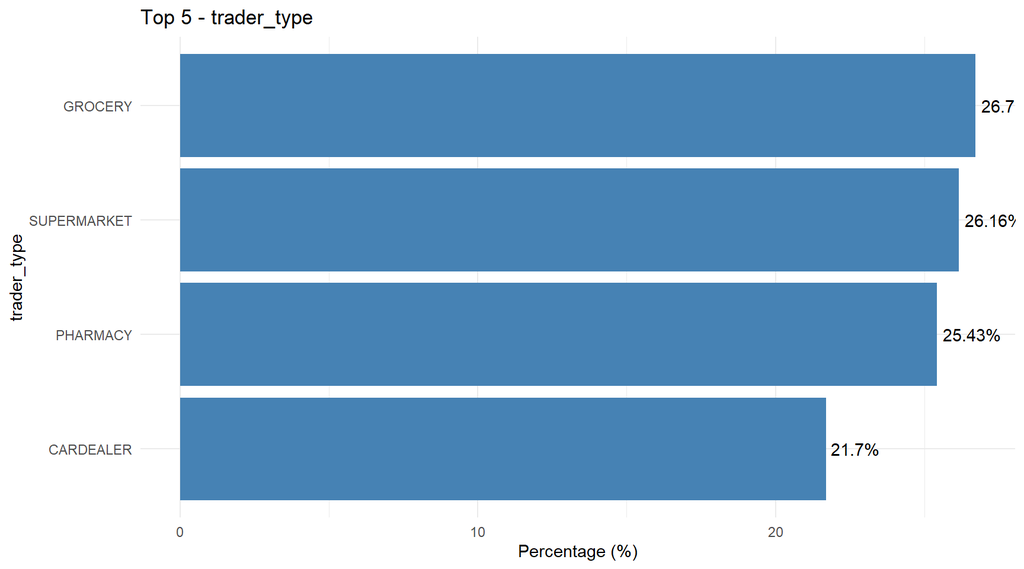

```
## Name:  num_products   Type:  IntegerType
```

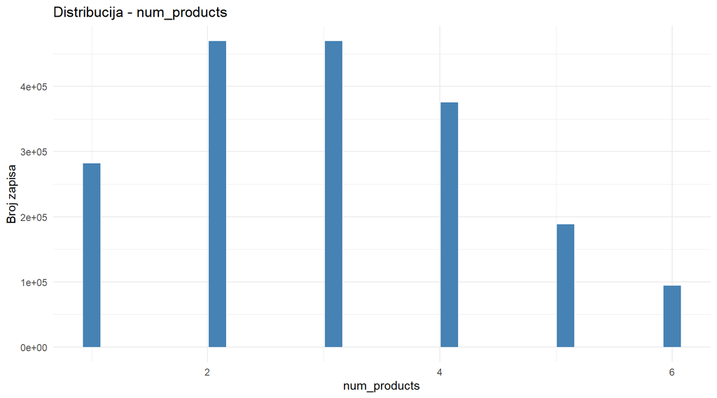

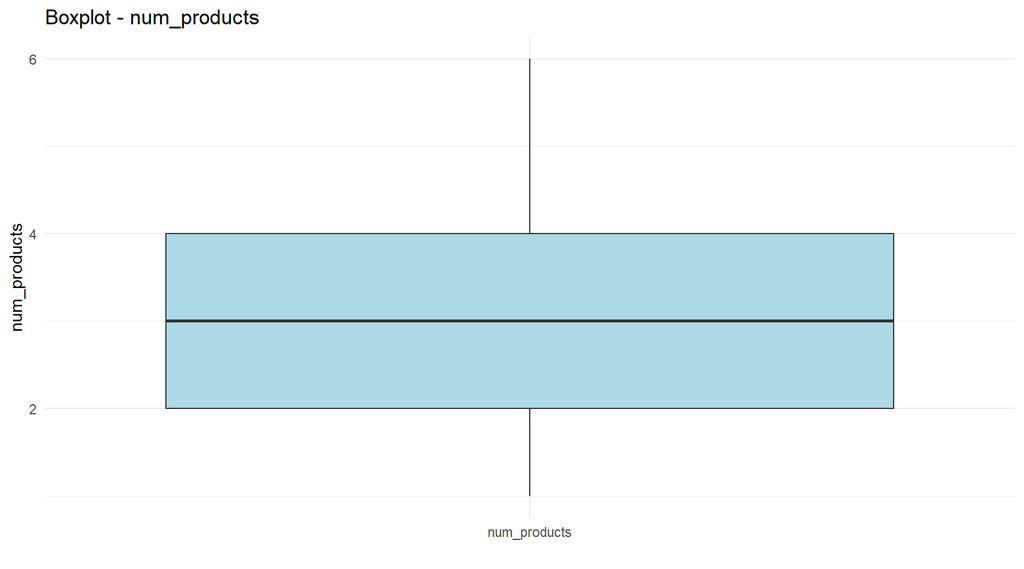

```
##       Metrics    Value
## 1         Min 1.000000
## 2         Max 6.000000
## 3     Average 2.999907
## 4     Std_Dev 1.378383
## 5      Median 3.000000
## 6 Quantile_25 2.000000
## 7 Quantile_75 4.000000
## Name:  date   Type:  TimestampType
```

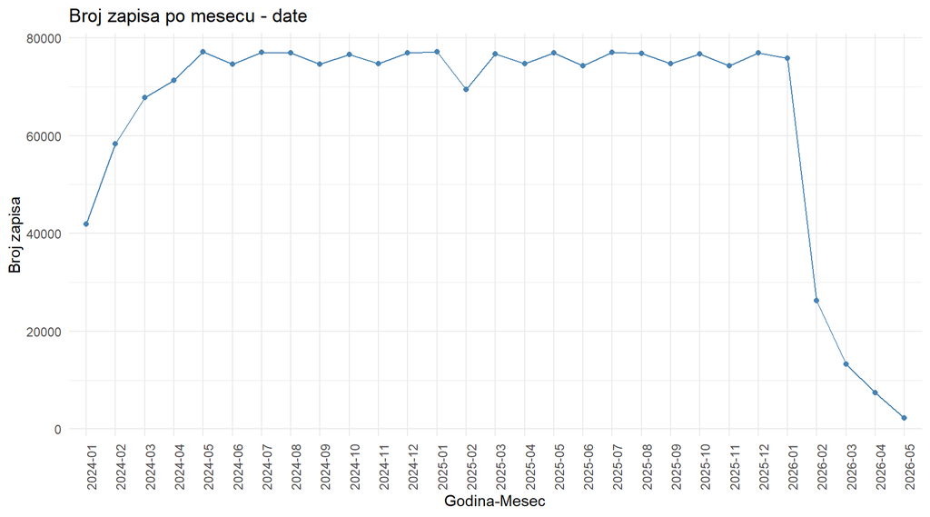

```
##       Metrics                   Value
## 1         Min 2024-01-02 03:38:24.124
## 2         Max 2026-05-27 20:07:34.138
## 3 Span (days)                   876.6
## Name:  day_of_week    Type:  IntegerType
```

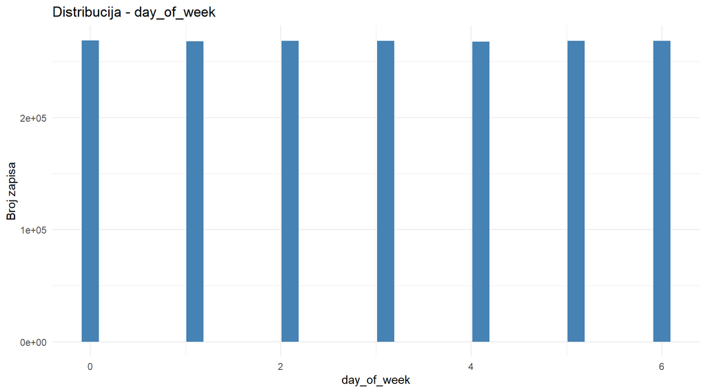

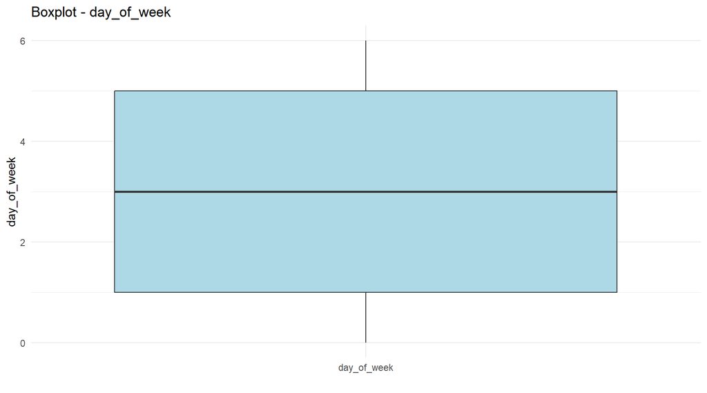

```
##       Metrics    Value
## 1         Min 0.000000
## 2         Max 6.000000
## 3     Average 2.999137
## 4     Std_Dev 2.000741
## 5      Median 3.000000
## 6 Quantile_25 1.000000
## 7 Quantile_75 5.000000
## Name:  month      Type:  IntegerType
```

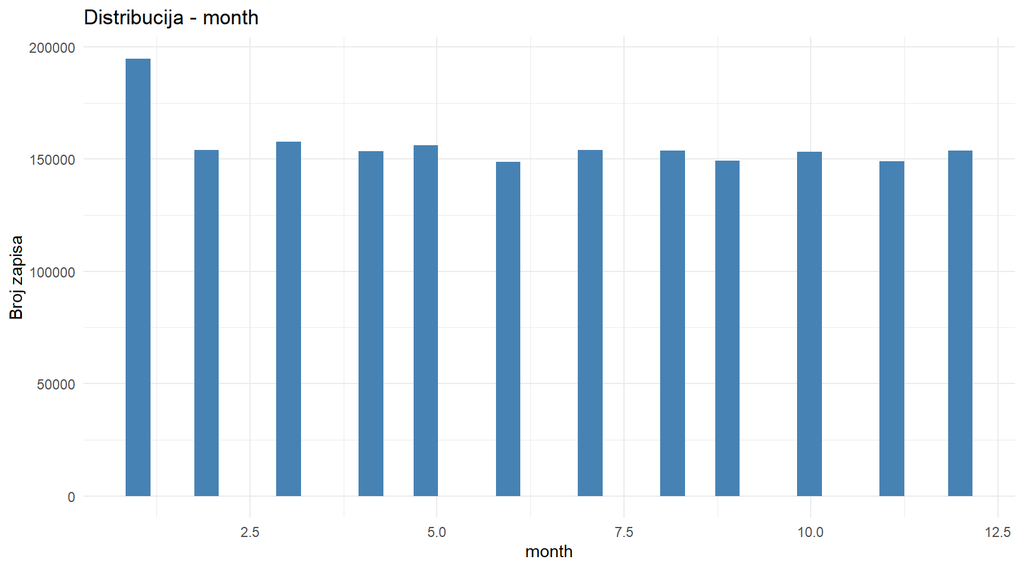

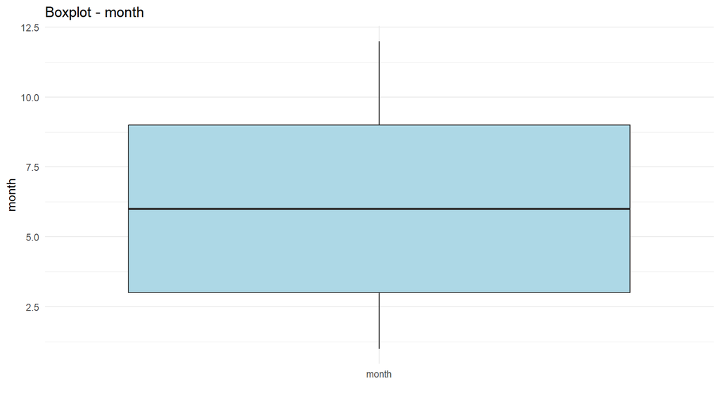

```
##       Metrics     Value
## 1         Min  1.000000
## 2         Max 12.000000
## 3     Average  6.353357
## 4     Std_Dev  3.508004
## 5      Median  6.000000
## 6 Quantile_25  3.000000
## 7 Quantile_75  9.000000
## Name:  quarter    Type:  IntegerType
```

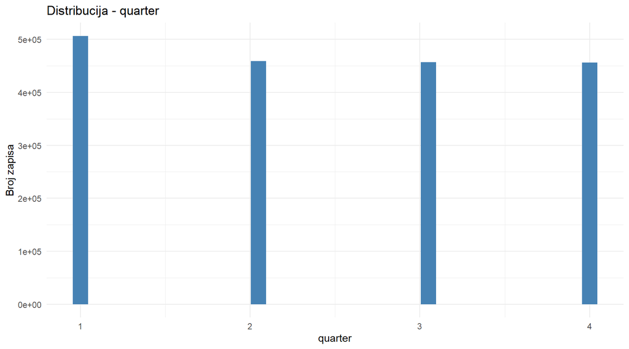

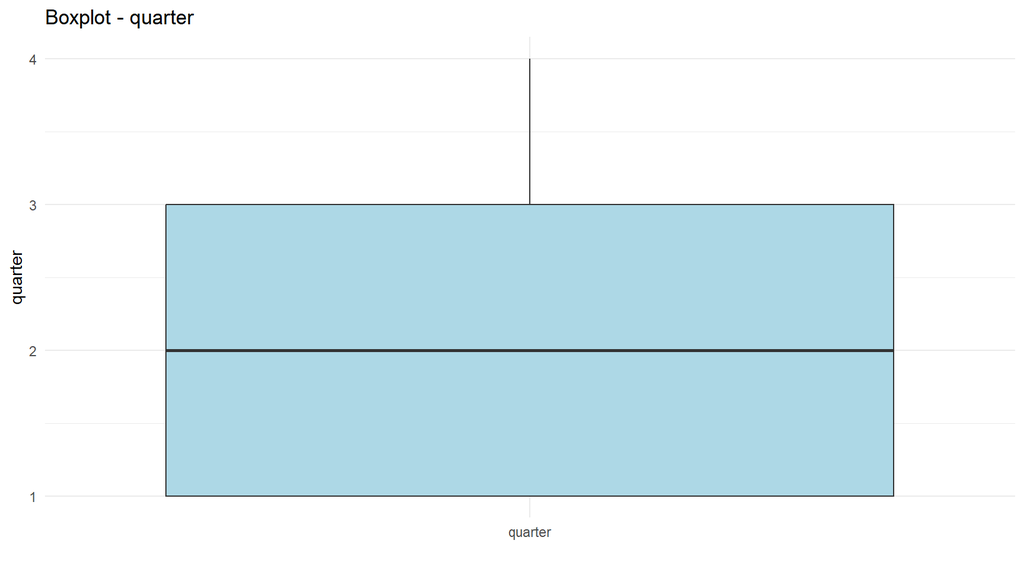

```
##       Metrics    Value
## 1         Min 1.000000
## 2         Max 4.000000
## 3     Average 2.459305
## 4     Std_Dev 1.128404
## 5      Median 2.000000
## 6 Quantile_25 1.000000
## 7 Quantile_75 3.000000
## Name:  total_cost     Type:  DoubleType
```

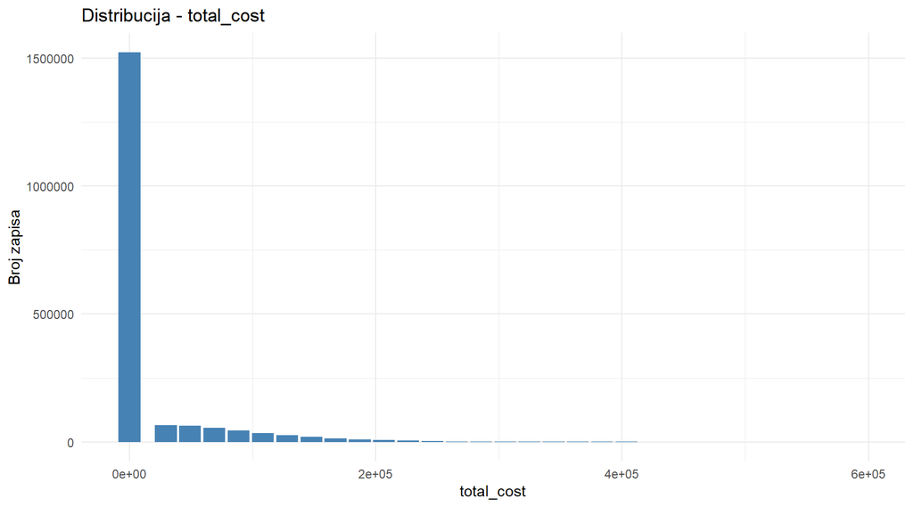

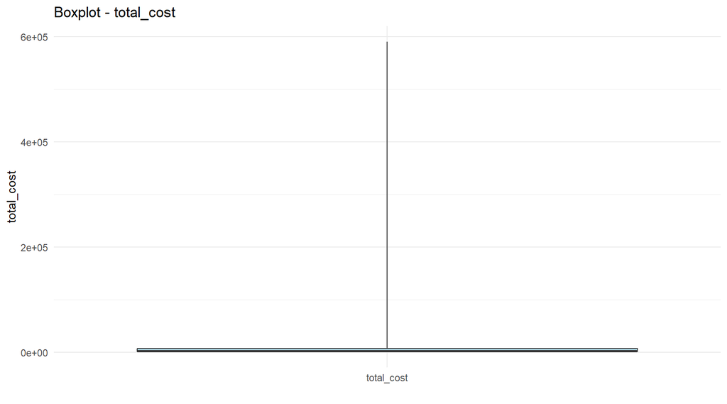

```
##       Metrics     Value
## 1         Min     30.06
## 2         Max 590489.70
## 3     Average  19278.77
## 4     Std_Dev  43026.50
## 5      Median   2280.24
## 6 Quantile_25   1049.01
## 7 Quantile_75   6477.33
## Name:  status     Type:  StringType
## # A tibble: 3 × 3
##   Value       Frequency Pct_Of_Total
##   <chr>           <dbl>        <dbl>
## 1 COMPLETED     1637618        87.2
## 2 IN_PROGRESS    144633         7.7
## 3 CANCELLED       96134         5.12
```

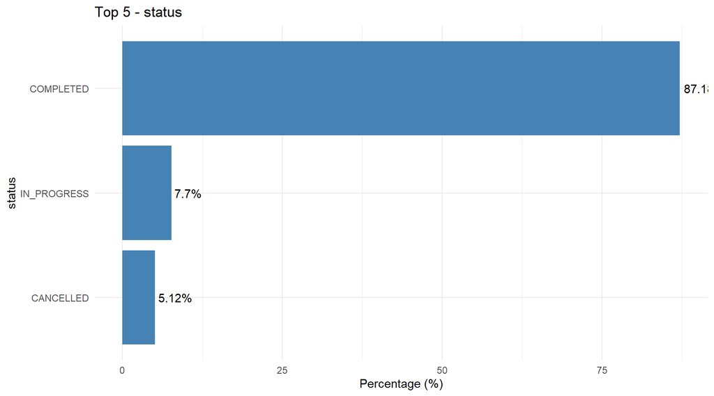

```
## Name:  deleted    Type:  BooleanType
```

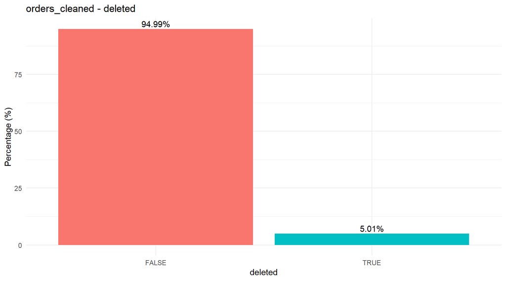

```
## # A tibble: 2 × 3
##   Value Frequency   Pct
##   <lgl>     <dbl> <dbl>
## 1 TRUE      94156  5.01
## 2 FALSE   1784229 95.0
## Name:  cancelled_date     Type:  StringType
## # A tibble: 5 × 3
##   Value                   Frequency Pct_Of_Total
##   <chr>                       <dbl>        <dbl>
## 1 Not Cancelled             1782251         94.9
## 2 2024-04-20 00:58:49.318         1          0
## 3 2024-05-17 03:39:50.534         1          0
## 4 2024-09-07 21:41:03.084         1          0
## 5 2024-10-27 02:08:23.115         1          0
```

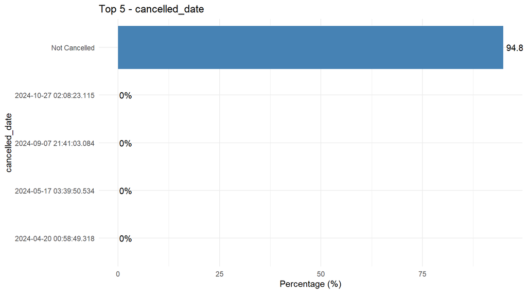

```
## Name:  cancelled_by   Type:  StringType
## # A tibble: 5 × 3
##   Value                                Frequency Pct_Of_Total
##   <chr>                                    <dbl>        <dbl>
## 1 Not Cancelled                          1782251         94.9
## 2 8cf603df-4281-42fa-9177-06ee0806e882         7          0
## 3 3c103b12-a8b0-4142-b448-a2fae3891a82         6          0
## 4 9663825c-c74f-4517-aaf5-db78b1de784f         6          0
## 5 033efafd-aa99-415d-a82c-746b6308d5b3         6          0
```

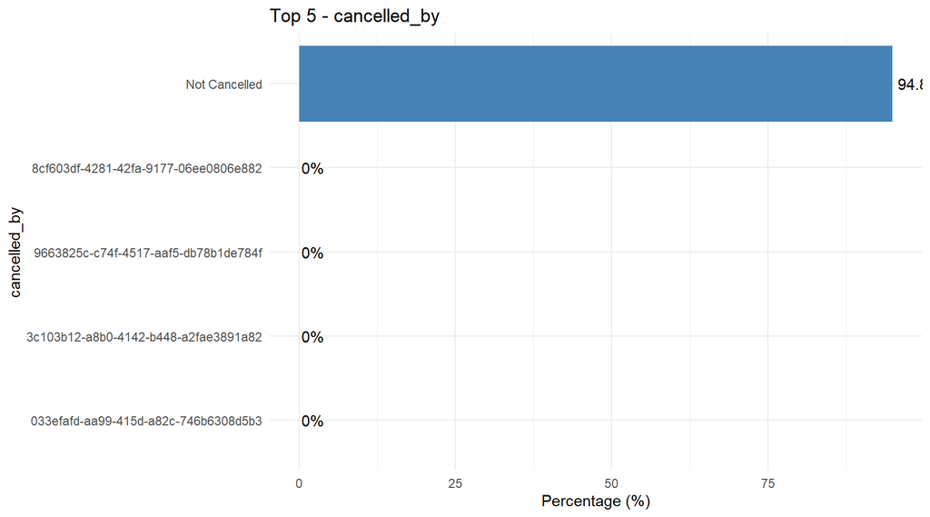

```r
analyze_and_visualize(order_products_cleaned)
```

```
## Name:  order_id   Type:  StringType
## # A tibble: 5 × 3
##   Value                                Frequency Pct_Of_Total
##   <chr>                                    <dbl>        <dbl>
## 1 60e9310f-ae07-495f-a484-31e3d541f552         8            0
## 2 24d13de8-86b0-45d7-acb0-8320322c295d         8            0
## 3 54d78d57-b6df-4097-b044-4a911b9eaa80         8            0
## 4 87bcd6a3-c021-4bd7-a604-b59408edea01         8            0
## 5 0d48bdff-b6ec-4ec0-94a4-ff6864167fa5         8            0
## # A tibble: 5 × 2
##   order_id                             Count
##   <chr>                                <dbl>
## 1 8f9eab17-eb8d-4c7c-98cc-030cabfabec8     8
## 2 25fe7ab2-8bac-40ee-8b4e-a7593199cb97     8
## 3 8ac65c36-d815-46c9-bd73-d732a34addee     8
## 4 809402fe-407b-4071-b262-e2ff741ed2d3     8
## 5 c57776ba-280d-44f6-8dc7-9db841a715e1     8
## Name:  line_no    Type:  IntegerType
```

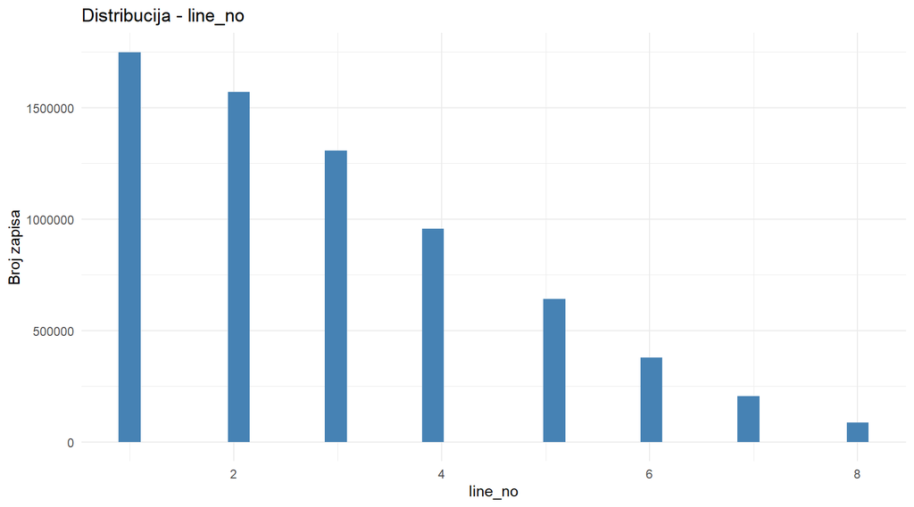

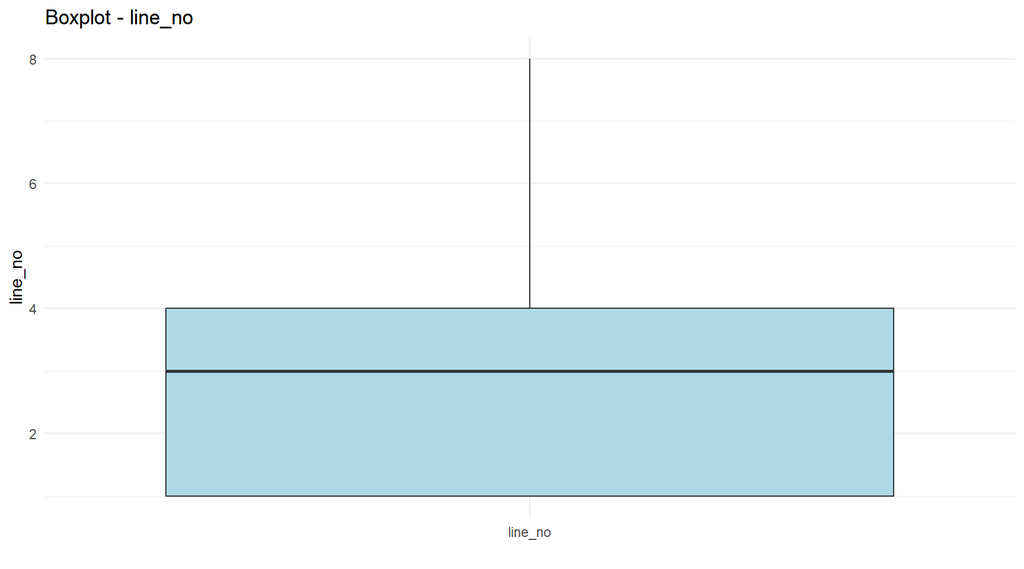

```
##       Metrics    Value
## 1         Min 1.000000
## 2         Max 8.000000
## 3     Average 2.935874
## 4     Std_Dev 1.740999
## 5      Median 3.000000
## 6 Quantile_25 1.000000
## 7 Quantile_75 4.000000
## Name:  product_id     Type:  StringType
## # A tibble: 5 × 3
##   Value                                Frequency Pct_Of_Total
##   <chr>                                    <dbl>        <dbl>
## 1 052f6d03-2c56-4973-b50e-de84bf505b49        35            0
## 2 4812aa9b-7411-4765-bf16-04d4f73ba337        33            0
## 3 1c754ba3-e5fc-4d66-9cb1-e3e9da5a32ab        33            0
## 4 27e39193-c3e9-4e6d-9f61-eae59bd00f2b        33            0
## 5 0291444b-c3b8-4443-b07a-19f0d05cb4b9        33            0
## # A tibble: 5 × 2
##   product_id                           Count
##   <chr>                                <dbl>
## 1 052f6d03-2c56-4973-b50e-de84bf505b49    35
## 2 27e39193-c3e9-4e6d-9f61-eae59bd00f2b    33
## 3 0291444b-c3b8-4443-b07a-19f0d05cb4b9    33
## 4 1c754ba3-e5fc-4d66-9cb1-e3e9da5a32ab    33
## 5 21e8a575-c5be-4190-8b9d-91aac4f2b783    33
## Name:  quantity   Type:  IntegerType
```

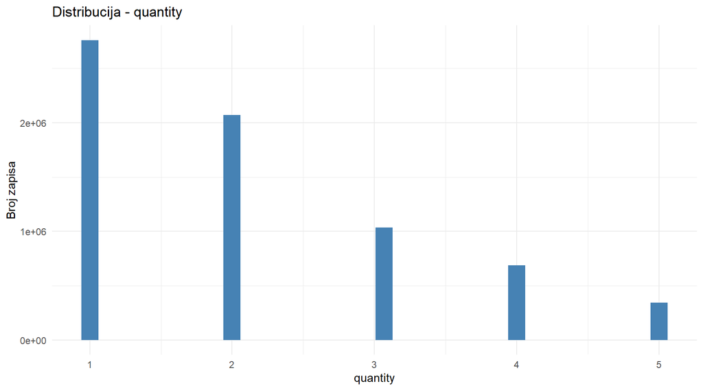

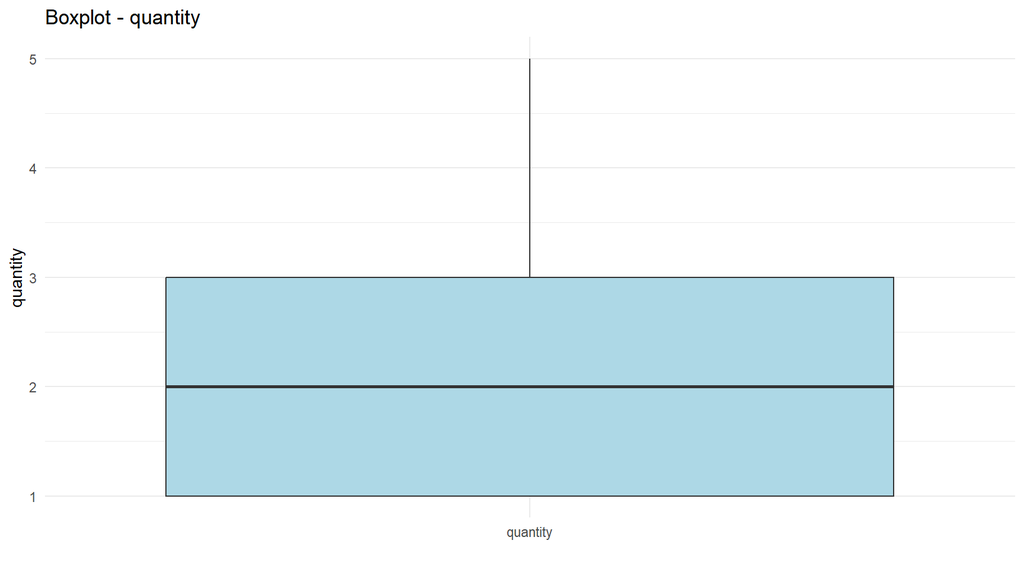

```
##       Metrics    Value
## 1         Min 1.000000
## 2         Max 5.000000
## 3     Average 2.098144
## 4     Std_Dev 1.177832
## 5      Median 2.000000
## 6 Quantile_25 1.000000
## 7 Quantile_75 3.000000
```

```r
analyze_and_visualize(receipt_products_cleaned)
```

```
## Name:  receipt_id     Type:  StringType
## # A tibble: 5 × 3
##   Value                                Frequency Pct_Of_Total
##   <chr>                                    <dbl>        <dbl>
## 1 77b31414-dd3d-4a7c-911b-2f148f21be74         6            0
## 2 042975d6-fb90-4ec1-8c1a-f3559275a633         6            0
## 3 6f758776-0894-42cd-8821-c8df8b6d46a1         6            0
## 4 ff8136d6-8ed3-406f-875c-80dcdc76db51         6            0
## 5 75808187-ae72-444e-9aec-b3d7eafce22e         6            0
## # A tibble: 5 × 2
##   receipt_id                           Count
##   <chr>                                <dbl>
## 1 3488116d-7dc2-4404-83cb-2f9ef1827c01     6
## 2 db3ea85d-61cb-4b0d-8d08-cf4e3d0f8f53     6
## 3 71a281f8-8edb-4072-bbc7-1a9410387d8e     6
## 4 fc5ca6fb-7096-48d8-b0a8-985075e59e24     6
## 5 d5274b7d-9492-42d1-9972-5b2057507d28     6
## Name:  line_no    Type:  IntegerType
```

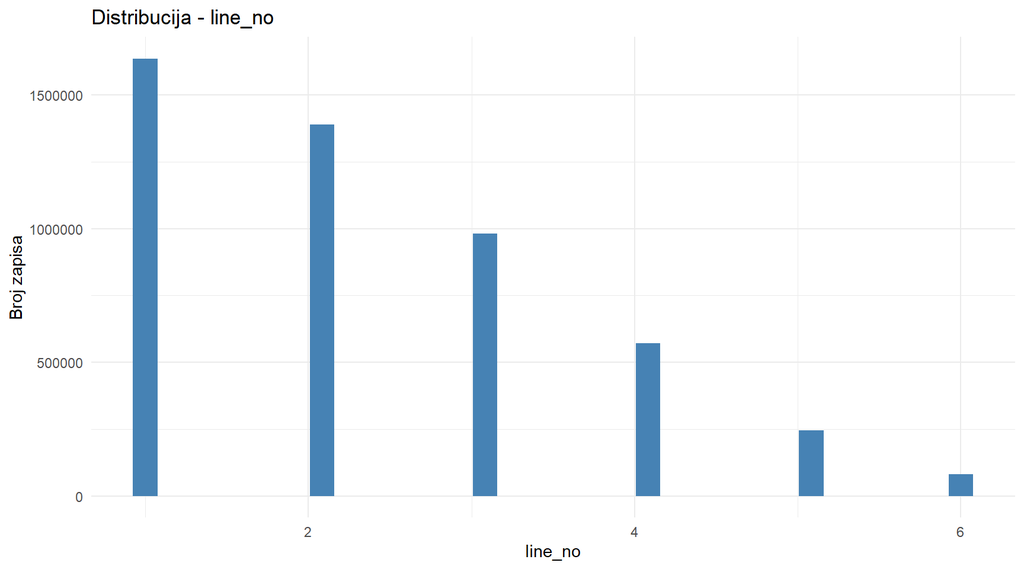

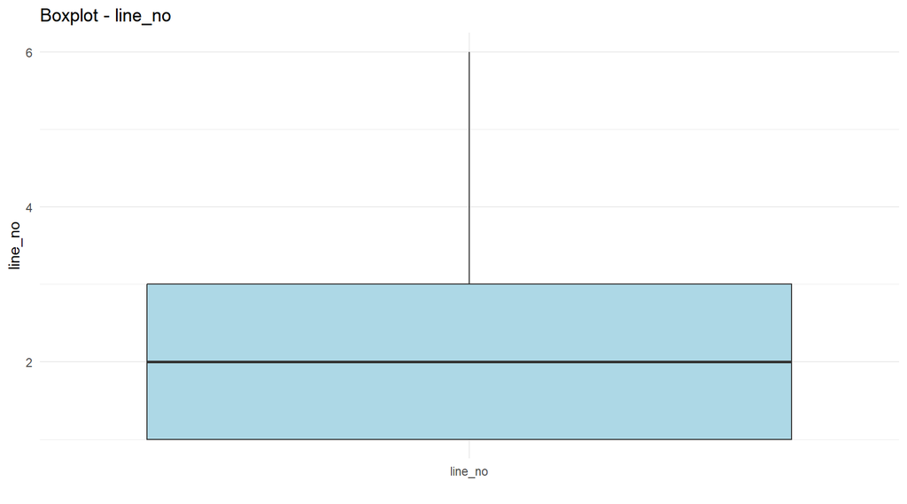

```
##       Metrics    Value
## 1         Min 1.000000
## 2         Max 6.000000
## 3     Average 2.316311
## 4     Std_Dev 1.271321
## 5      Median 2.000000
## 6 Quantile_25 1.000000
## 7 Quantile_75 3.000000
## Name:  product_id     Type:  StringType
## # A tibble: 5 × 3
##   Value                                Frequency Pct_Of_Total
##   <chr>                                    <dbl>        <dbl>
## 1 031f2efd-7b90-4cf3-a726-5adc51c0707c        27            0
## 2 b639b3d9-dd85-4ef0-9f4a-9f36f8f2d2bf        27            0
## 3 65232b66-04de-4f32-8cb6-1470755b8099        26            0
## 4 aff8cd92-8b14-41b6-97ab-5266525a4cf8        26            0
## 5 4c2bfce1-0edb-4311-8fc2-3975bb237505        26            0
## # A tibble: 5 × 2
##   product_id                           Count
##   <chr>                                <dbl>
## 1 031f2efd-7b90-4cf3-a726-5adc51c0707c    27
## 2 b639b3d9-dd85-4ef0-9f4a-9f36f8f2d2bf    27
## 3 deca0cfd-fb44-484b-b2ab-bd14e43dc9aa    26
## 4 aff8cd92-8b14-41b6-97ab-5266525a4cf8    26
## 5 65232b66-04de-4f32-8cb6-1470755b8099    26
## Name:  quantity   Type:  IntegerType
```

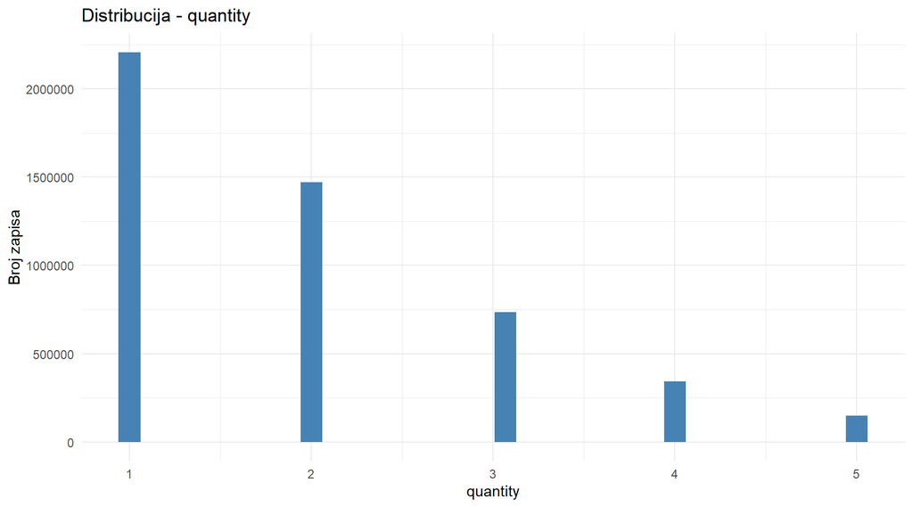

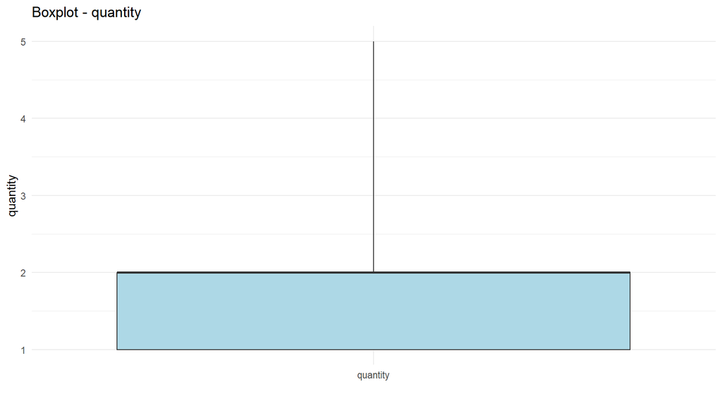

```
##       Metrics    Value
## 1         Min 1.000000
## 2         Max 5.000000
## 3     Average 1.929690
## 4     Std_Dev 1.069927
## 5      Median 2.000000
## 6 Quantile_25 1.000000
## 7 Quantile_75 2.000000
```

```r
analyze_and_visualize(trader_products_cleaned)
```

```
## Name:  trader_id      Type:  StringType
## # A tibble: 5 × 3
##   Value                                Frequency Pct_Of_Total
##   <chr>                                    <dbl>        <dbl>
## 1 f658815b-c008-4d59-9165-b40353ce8cc0       199            0
## 2 0d6e6296-8396-4082-8525-a021ecb400f0       180            0
## 3 63b4e099-3d08-4d9a-a797-444c4b3bc5e5       179            0
## 4 0ba7ae60-8eb4-46e8-9003-05a69f900027       176            0
## 5 0d543a70-d624-428c-b0ec-2bbc44922e8e       174            0
## # A tibble: 5 × 2
##   trader_id                            Count
##   <chr>                                <dbl>
## 1 f658815b-c008-4d59-9165-b40353ce8cc0   199
## 2 0d6e6296-8396-4082-8525-a021ecb400f0   180
## 3 63b4e099-3d08-4d9a-a797-444c4b3bc5e5   179
## 4 0ba7ae60-8eb4-46e8-9003-05a69f900027   176
## 5 0d543a70-d624-428c-b0ec-2bbc44922e8e   174
## Name:  product_id     Type:  StringType
## # A tibble: 5 × 3
##   Value                                Frequency Pct_Of_Total
##   <chr>                                    <dbl>        <dbl>
## 1 2d1a8b4f-99c1-415f-830c-05abe42e98ed        31            0
## 2 c8e00474-a73b-4bbf-b37d-5e39d2566dc0        31            0
## 3 e2772a64-bdce-4613-bf56-1d0c23f0d2f9        30            0
## 4 b639b3d9-dd85-4ef0-9f4a-9f36f8f2d2bf        30            0
## 5 deca0cfd-fb44-484b-b2ab-bd14e43dc9aa        30            0
## # A tibble: 5 × 2
##   product_id                           Count
##   <chr>                                <dbl>
## 1 c8e00474-a73b-4bbf-b37d-5e39d2566dc0    31
## 2 2d1a8b4f-99c1-415f-830c-05abe42e98ed    31
## 3 b639b3d9-dd85-4ef0-9f4a-9f36f8f2d2bf    30
## 4 e2772a64-bdce-4613-bf56-1d0c23f0d2f9    30
## 5 deca0cfd-fb44-484b-b2ab-bd14e43dc9aa    30
## Name:  available_quantity     Type:  IntegerType
```

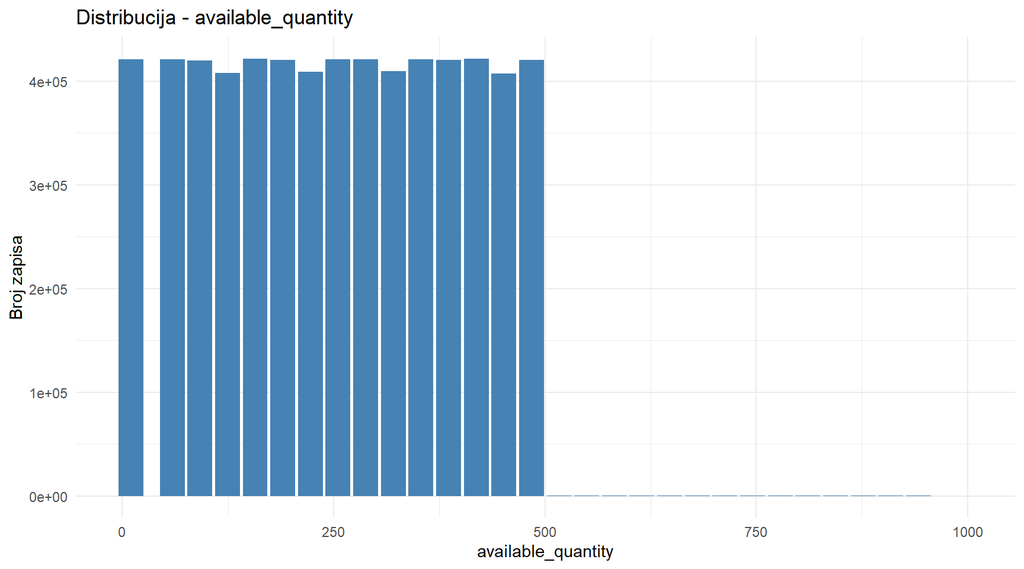

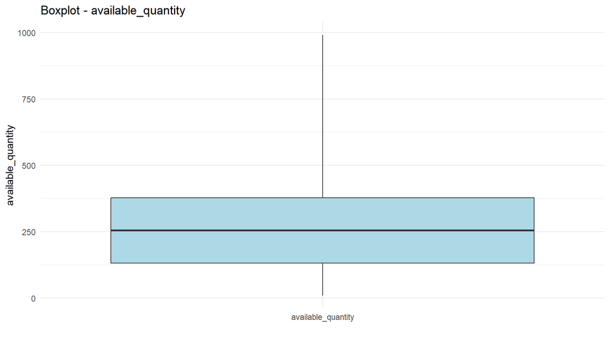

```
##       Metrics    Value
## 1         Min  10.0000
## 2         Max 991.0000
## 3     Average 255.0787
## 4     Std_Dev 141.8124
## 5      Median 255.0000
## 6 Quantile_25 132.0000
## 7 Quantile_75 378.0000
```

## 5.2 Analiza odnosa

Pored generičke analize atributa, sprovedena je analiza specifičnih odnosa unutar podataka.

### 5.2.1 Rokovi isporuke po tipu trgovca

Prosječni rok isporuke (`lead_days`) se analizira po kategorijama tipova trgovaca. Ova analiza otkriva razlike u operativnoj efikasnosti između različitih tipova prodavaca na platformi.

```
## # A tibble: 4 × 2
##   trader_type mean_lead_days
##   <chr>                <dbl>
## 1 SUPERMARKET           7.47
## 2 GROCERY               3.98
## 3 CARDEALER            75.0
## 4 PHARMACY             16.5
```

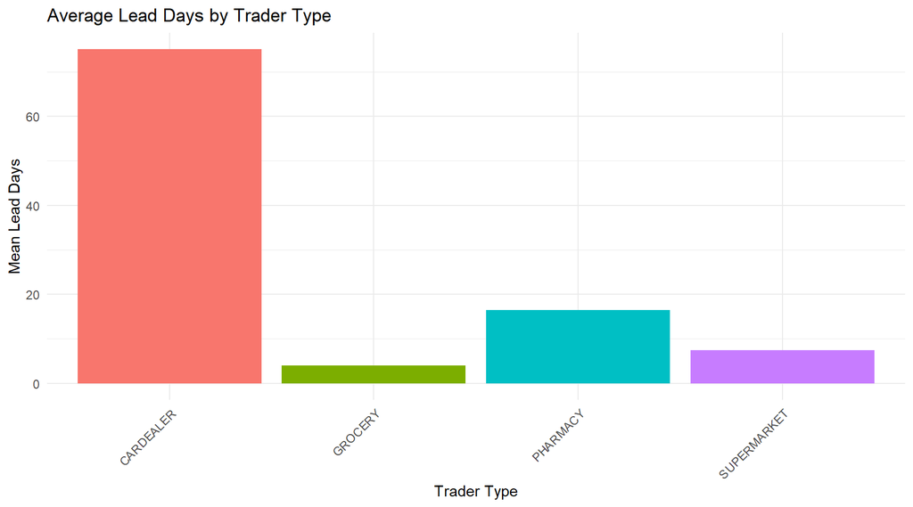

```r
analyze_trader_lead_days <- function(spark_df) {
  summary_data <- spark_df %>%
    filter(!is.na(trader_type) & !is.na(lead_days)) %>%
    group_by(trader_type) %>%
    summarise(mean_lead_days = mean(lead_days, na.rm = TRUE)) %>%
    collect()

  print(summary_data)

  ggplot(summary_data, aes(x = trader_type, y = mean_lead_days, fill = trader_type)) +
    geom_bar(stat = "identity", show.legend = FALSE) +
    theme_minimal() +
    labs(
      title = "Average Lead Days by Trader Type",
      x = "Trader Type",
      y = "Mean Lead Days"
    ) +
    theme(axis.text.x = element_text(angle = 45, hjust = 1))
}
analyze_trader_lead_days(orders_cleaned)
```

### 5.2.2 Prosječni troškovi po statusu narudžbine

Analiza prosječnog ukupnog troška (`total_cost`) grupovana po statusu narudžbine pruža uvid u to da li postoji korelacija između vrijednosti narudžbine i vjerovatnoće njenog otkazivanja ili uspješnog završetka.

```
## # A tibble: 5 × 2
##   status    mean_total_cost
##   <chr>               <dbl>
## 1 APPROVED           44171.
## 2 COMPLETED           7127.
## 3 PENDING            62267.
## 4 FULFILLED           9373.
## 5 CANCELLED          62499.
```

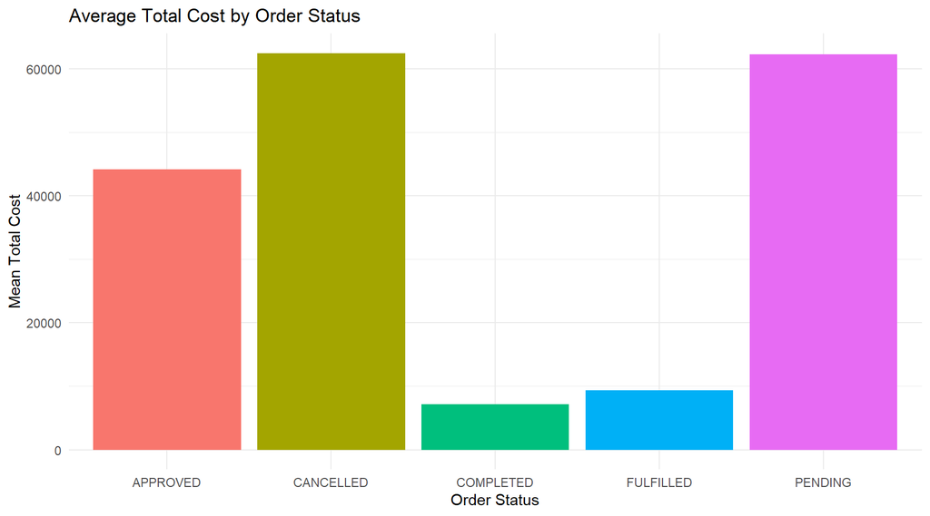

```r
analyze_status_total_cost <- function(spark_df) {
  summary_data <- spark_df %>%
    filter(!is.na(status) & !is.na(total_cost)) %>%
    group_by(status) %>%
    summarise(mean_total_cost = mean(total_cost, na.rm = TRUE)) %>%
    collect()

  print(summary_data)

  ggplot(summary_data, aes(x = status, y = mean_total_cost, fill = status)) +
    geom_bar(stat = "identity", show.legend = FALSE) +
    theme_minimal() +
    labs(
      title = "Average Total Cost by Order Status",
      x = "Order Status",
      y = "Mean Total Cost"
    )
}
analyze_status_total_cost(orders_cleaned)
```

### 5.2.3 Distribucija statusa narudžbine po tipu trgovca

Grafikon prikazuje relativni udio pojedinih statusa (završena, otkazana, u toku itd.) unutar svake kategorije trgovaca. Ovakva analiza može ukazati na sistemske probleme kod određenih tipova partnera.

```
## # A tibble: 20 × 3
##    trader_type status         n
##    <chr>       <chr>      <dbl>
##  1 GROCERY     APPROVED   55319
##  2 GROCERY     PENDING    28527
##  3 GROCERY     COMPLETED 294549
##  4 SUPERMARKET COMPLETED 202488
##  5 GROCERY     FULFILLED 136771
##  6 CARDEALER   COMPLETED  26447
##  7 CARDEALER   FULFILLED  27886
##  8 GROCERY     CANCELLED  21142
##  9 PHARMACY    COMPLETED 162220
## 10 SUPERMARKET PENDING    40314
## 11 CARDEALER   CANCELLED  86085
## 12 SUPERMARKET APPROVED   83979
## 13 SUPERMARKET CANCELLED  32533
## 14 CARDEALER   APPROVED  145141
## 15 SUPERMARKET FULFILLED 165818
## 16 PHARMACY    CANCELLED  31487
## 17 PHARMACY    FULFILLED 136247
## 18 CARDEALER   PENDING   150241
## 19 PHARMACY    PENDING    67730
## 20 PHARMACY    APPROVED  112625
```

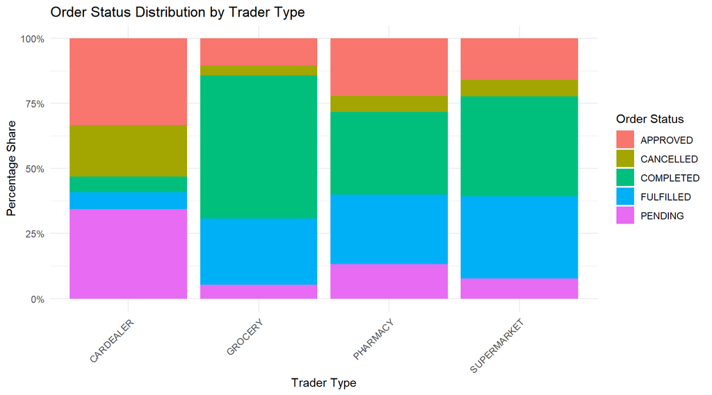

```r
analyze_trader_status_distribution <- function(spark_df) {
  summary_data <- spark_df %>%
    filter(!is.na(trader_type) & !is.na(status)) %>%
    group_by(trader_type, status) %>%
    count() %>%
    collect()

  print(summary_data)

  ggplot(summary_data, aes(x = trader_type, y = n, fill = status)) +
    geom_bar(stat = "identity", position = "fill") +
    scale_y_continuous(labels = scales::percent) +
    theme_minimal() +
    labs(
      title = "Order Status Distribution by Trader Type",
      x = "Trader Type",
      y = "Percentage Share",
      fill = "Order Status"
    ) +
    theme(axis.text.x = element_text(angle = 45, hjust = 1))
}
analyze_trader_status_distribution(orders_cleaned)
```

### 5.2.4 Status narudžbine u zavisnosti od broja proizvoda

Ispituje se da li kompleksnost narudžbine, mjerena brojem stavki (`num_products`), utiče na ishod narudžbine. Složenije narudžbine potencijalno nose veći rizik od kašnjenja ili otkazivanja.

```
## # A tibble: 40 × 3
##    num_products status        n
##           <int> <chr>     <dbl>
##  1            1 COMPLETED 76198
##  2            2 FULFILLED 71078
##  3            8 CANCELLED 12151
##  4            8 FULFILLED 22006
##  5            2 CANCELLED 22723
##  6            4 APPROVED  72063
##  7            7 PENDING   20337
##  8            7 FULFILLED 31169
##  9            7 COMPLETED 42840
## 10            6 APPROVED  39195
## # ℹ 30 more rows
```

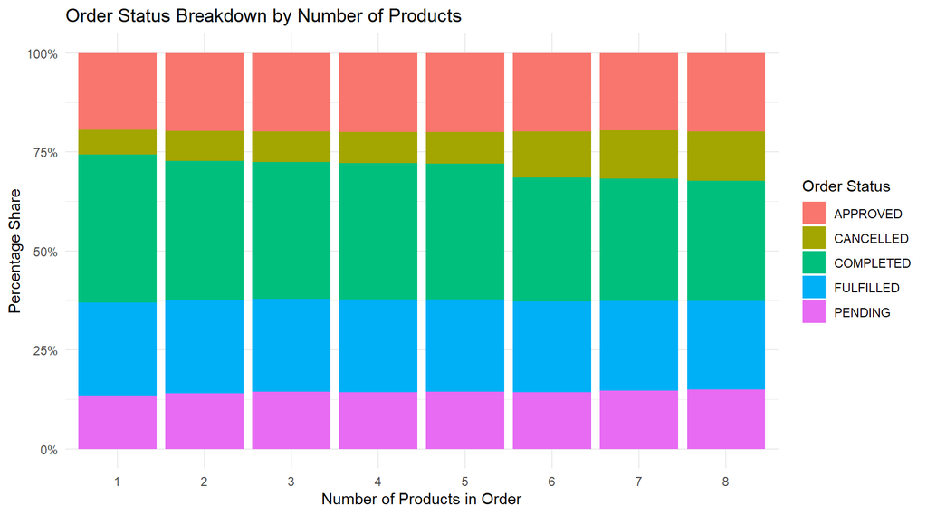

```r
analyze_num_products_status <- function(spark_df) {
  summary_data <- spark_df %>%
    filter(!is.na(num_products) & !is.na(status)) %>%
    group_by(num_products, status) %>%
    count() %>%
    collect()

  print(summary_data)

  ggplot(summary_data, aes(x = factor(num_products), y = n, fill = status)) +
    geom_bar(stat = "identity", position = "fill") +
    scale_y_continuous(labels = scales::percent) +
    theme_minimal() +
    labs(
      title = "Order Status Breakdown by Number of Products",
      x = "Number of Products in Order",
      y = "Percentage Share",
      fill = "Order Status"
    )
}
analyze_num_products_status(orders_cleaned)
```

### 5.2.5 Prosječni troškovi po tipu trgovca

Poređenje prosječnih i medijanskih ukupnih troškova narudžbi grupisanih po tipu trgovca rasvjetljava razlike u cjenovnom pozicioniranju između različitih kategorija poslovnih partnera.

```
## # A tibble: 4 × 3
##   trader_type mean_total_cost median_total_cost
##   <chr>                 <dbl>             <dbl>
## 1 SUPERMARKET           2938.             2272.
## 2 GROCERY               2371.             1855.
## 3 CARDEALER           115295.            98614.
## 4 PHARMACY              4511.             3824.
```

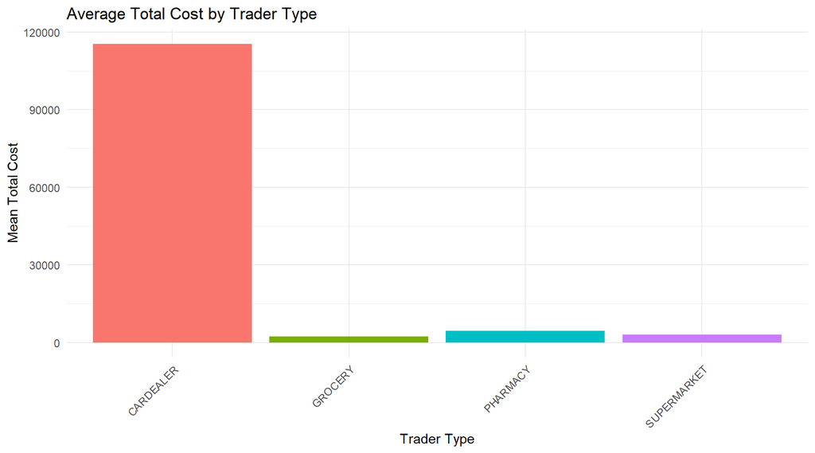

```r
analyze_trader_total_cost <- function(spark_df) {
  summary_data <- spark_df %>%
    filter(!is.na(trader_type) & !is.na(total_cost)) %>%
    group_by(trader_type) %>%
    summarise(
      mean_total_cost = mean(total_cost, na.rm = TRUE),
      median_total_cost = percentile_approx(total_cost, 0.5)
    ) %>%
    collect()

  print(summary_data)

  ggplot(summary_data, aes(x = trader_type, y = mean_total_cost, fill = trader_type)) +
    geom_bar(stat = "identity", show.legend = FALSE) +
    theme_minimal() +
    labs(
      title = "Average Total Cost by Trader Type",
      x = "Trader Type",
      y = "Mean Total Cost"
    ) +
    theme(axis.text.x = element_text(angle = 45, hjust = 1))
}
analyze_trader_total_cost(orders_cleaned)
```

# 6 Inženjering karakteristika

## 6.1 Prozorske funkcije i agregacija

Priprema podataka za modelovanje zahtijeva kreiranje kontekstualnih karakteristika koje opisuju istorijsko ponašanje svakog korisnika i trgovca u trenutku izvršenja svake narudžbine. Primijenjene prozori - (*window*) funkcije unutar Spark okruženja:

- `user_order_count` – broj prethodnih narudžbina datog korisnika (isključujući tekuću)
- `user_avg_cost` – kumulativni prosječni trošak prethodnih narudžbina korisnika
- `user_cancelled_count` – broj prethodno otkazanih narudžbina korisnika
- `trader_order_count` – broj prethodno obrađenih narudžbina za dati tip trgovca
- `trader_avg_cost` – kumulativni prosječni trošak za dati tip trgovca

Sve karakteristike su računate na osnovu podataka koji su bili dostupni **prije** tekuće narudžbine (lag pristup), čime se izbjegava curenje podataka (*data leakage*) u modelima.

```r
user_window <- orders_cleaned %>%
  sdf_repartition(partitions = 4) %>%
  arrange(user_id, created_date) %>%
  group_by(user_id) %>%
  mutate(
    user_order_count = row_number() - 1,
    user_avg_cost = (cumsum(total_cost) - total_cost) / pmax(row_number() - 1, 1),
    user_cancelled_count = cumsum(ifelse(status == "CANCELLED", 1, 0)) -
      ifelse(status == "CANCELLED", 1, 0)
  ) %>%
  ungroup() %>%
  sdf_persist(storage.level = "MEMORY_AND_DISK")

trader_window <- user_window %>%
  sdf_repartition(partitions = 4) %>%
  arrange(trader_type, created_date) %>%
  group_by(trader_type) %>%
  mutate(
    trader_order_count = row_number() - 1,
    trader_avg_cost = (cumsum(total_cost) - total_cost) / pmax(row_number() - 1, 1)
  ) %>%
  ungroup() %>%
  sdf_persist(storage.level = "MEMORY_AND_DISK")

orders_features <- trader_window %>%
  mutate(
    user_order_count = ifelse(is.na(user_order_count), 0, user_order_count),
    user_avg_cost = ifelse(is.na(user_avg_cost), 0, user_avg_cost),
    user_cancelled_count = ifelse(is.na(user_cancelled_count), 0, user_cancelled_count),
    trader_order_count = ifelse(is.na(trader_order_count), 0, trader_order_count),
    trader_avg_cost = ifelse(is.na(trader_avg_cost), 0, trader_avg_cost)
  )
```

## 6.2 Kodiranje kategoričkih varijabli i skaliranje

Za potrebe modela mašinskog učenja, kategoričke varijable (`trader_type`, `day_of_week`) kodirane su kroz StringIndexer i OneHotEncoder transformacije. Numeričke karakteristike su standardizovane primjenom StandardScaler-a. Sve karakteristike su zatim objedinjene u jedinstveni feature vektor unutar Spark ML pipeline-a.

```r
model_data <- orders_features %>%
  ft_string_indexer(input_col = "trader_type", output_col = "trader_type_idx") %>%
  ft_one_hot_encoder(input_col = "trader_type_idx", output_col = "trader_type_oh") %>%
  ft_string_indexer(input_col = "day_of_week", output_col = "day_of_week_idx") %>%
  ft_one_hot_encoder(input_col = "day_of_week_idx", output_col = "day_of_week_oh") %>%
  ft_string_indexer(input_col = "status", output_col = "label")

model_data <- model_data %>%
  ft_vector_assembler(
    input_cols = c("total_cost", "num_products", "lead_days",
                   "user_order_count", "user_avg_cost", "user_cancelled_count",
                   "trader_order_count", "trader_avg_cost"),
    output_col = "numeric_features"
  ) %>%
  ft_standard_scaler(
    input_col = "numeric_features",
    output_col = "numeric_features_scaled"
  )

feature_cols <- c(
  "trader_type_oh", "day_of_week_oh",
  "numeric_features_scaled"
)

model_data <- model_data %>%
  ft_vector_assembler(input_cols = feature_cols, output_col = "features")

class_balance <- model_data %>% count(status) %>% collect()
print(class_balance)
```

```
## # A tibble: 5 × 2
##   status         n
##   <chr>      <dbl>
## 1 APPROVED  397064
## 2 COMPLETED 685704
## 3 PENDING   286812
## 4 FULFILLED 466722
## 5 CANCELLED 171247
```

```r
set.seed(42)
train_list <- list()
test_list <- list()

class_balance <- orders_features %>% count(status) %>% collect()
print(class_balance)
```

```
## # A tibble: 5 × 2
##   status         n
##   <chr>      <dbl>
## 1 APPROVED  397064
## 2 COMPLETED 685704
## 3 PENDING   286812
## 4 FULFILLED 466722
## 5 CANCELLED 171247
```

```r
statuses <- orders_features %>%
  distinct(status) %>%
  collect() %>%
  pull(status)

train_list <- list()
test_list <- list()

for (s in statuses) {
  subset <- orders_features %>% filter(status == s)
  sp <- sdf_random_split(subset, train = 0.8, test = 0.2, seed = 42)
  train_list[[s]] <- sp$train
  test_list[[s]] <- sp$test
}

train <- sdf_bind_rows(train_list) %>%
  sdf_repartition(partitions = 32) %>%
  sdf_persist(storage.level = "MEMORY_AND_DISK")

test <- sdf_bind_rows(test_list) %>%
  sdf_repartition(partitions = 32) %>%
  sdf_persist(storage.level = "MEMORY_AND_DISK")
```

# 7 Klasifikacija statusa narudžbine

Podaci su podijeljeni na trening (80%) i test (20%) skup uz stratifikovano uzorkovanje po statusu narudžbine, kako bi se osigurala reprezentativna distribucija klasa u oba skupa.

## 7.1 Logistička regresija

Logistička regresija je odabrana kao bazični (*baseline*) model zbog interpretabilnosti i brzine treniranja. Optimizacija hiperparametara sprovedena je metodom unakrsne validacije (3-struka) kroz mrežno pretraživanje (*grid search*) po parametrima regularizacije (`reg_param`) i tipa regularizacije (`elastic_net_param`).

```r
train <- sdf_repartition(train, partitions = 1)
test <- sdf_repartition(test, partitions = 1)

feature_cols <- c(
  "trader_type_oh", "day_of_week_oh",
  "numeric_features_scaled"
)

numeric_cols <- c("total_cost", "num_products", "lead_days",
                  "user_order_count", "user_avg_cost", "user_cancelled_count",
                  "trader_order_count", "trader_avg_cost")
metrics <- c("f1", "accuracy", "weightedPrecision", "weightedRecall")
evaluator <- ml_multiclass_classification_evaluator(sc, label_col = "label", metric_name = "f1")

# logistic_regression
lr_pipeline <- ml_pipeline(sc) %>%
  ft_string_indexer(input_col = "trader_type", output_col = "trader_type_idx") %>%
  ft_one_hot_encoder(input_col = "trader_type_idx", output_col = "trader_type_oh") %>%
  ft_string_indexer(input_col = "day_of_week", output_col = "day_of_week_idx") %>%
  ft_one_hot_encoder(input_col = "day_of_week_idx", output_col = "day_of_week_oh") %>%
  ft_string_indexer(input_col = "status", output_col = "label") %>%
  ft_vector_assembler(input_cols = numeric_cols, output_col = "numeric_features") %>%
  ft_standard_scaler(input_col = "numeric_features", output_col = "numeric_features_scaled") %>%
  ft_vector_assembler(input_cols = feature_cols, output_col = "features") %>%
  ml_logistic_regression(features_col = "features", label_col = "label")

lr_grid <- list(
  logistic_regression = list(
    reg_param = c(0.01, 0.1, 0.5),
    elastic_net_param = c(0.0, 0.5, 1.0)
  )
)

lr_cv <- ml_cross_validator(
  sc,
  estimator = lr_pipeline,
  estimator_param_maps = lr_grid,
  evaluator = evaluator,
  num_folds = 3
)

lr_cv_model <- ml_fit(lr_cv, train)

lr_results <- ml_validation_metrics(lr_cv_model)
print("LR Performances per scenario:")
```

```
## [1] "LR Performances per scenario:"
```

```r
print(lr_results)
```

```
##          f1 reg_param_1 elastic_net_param_1
## 1 0.2822958        0.01                 0.0
## 2 0.2888059        0.10                 0.0
## 3 0.2696317        0.50                 0.0
## 4 0.2778036        0.01                 0.5
## 5 0.2684528        0.10                 0.5
## 6 0.1738659        0.50                 0.5
## 7 0.2884485        0.01                 1.0
## 8 0.2134770        0.10                 1.0
## 9 0.1738659        0.50                 1.0
```

```r
test_pred_lr <- ml_transform(lr_cv_model$best_model, test)

test_metrics_lr <- lapply(metrics, function(m) {
  ev <- ml_multiclass_classification_evaluator(sc, label_col = "label", metric_name = m)
  ml_evaluate(ev, test_pred_lr)
})
names(test_metrics_lr) <- metrics

print("LR Test metrics:")
```

```
## [1] "LR Test metrics:"
```

```r
print(test_metrics_lr)
```

```
## $f1
## [1] 0.2886462
##
## $accuracy
## [1] 0.4018327
##
## $weightedPrecision
## [1] 0.259116
##
## $weightedRecall
## [1] 0.4018327
```

## 7.2 Random Forest

```r
rf_pipeline <- ml_pipeline(sc) %>%
  ft_string_indexer(input_col = "trader_type", output_col = "trader_type_idx") %>%
  ft_one_hot_encoder(input_col = "trader_type_idx", output_col = "trader_type_oh") %>%
  ft_string_indexer(input_col = "day_of_week", output_col = "day_of_week_idx") %>%
  ft_one_hot_encoder(input_col = "day_of_week_idx", output_col = "day_of_week_oh") %>%
  ft_string_indexer(input_col = "status", output_col = "label") %>%
  ft_vector_assembler(input_cols = numeric_cols, output_col = "numeric_features") %>%
  ft_standard_scaler(input_col = "numeric_features", output_col = "numeric_features_scaled") %>%
  ft_vector_assembler(input_cols = feature_cols, output_col = "features") %>%
  ml_random_forest_classifier(
    features_col = "features",
    label_col = "label",
    num_trees = 20,
    max_depth = 5,
    seed = 123
  )

rf_grid <- list(
  random_forest_classifier = list(
    num_trees = c(10L, 20L),
    max_depth = c(3L, 5L)
  )
)

rf_cv <- ml_cross_validator(
  sc,
  estimator = rf_pipeline,
  estimator_param_maps = rf_grid,
  evaluator = evaluator,
  num_folds = 3
)

rf_cv_model <- ml_fit(rf_cv, train)

rf_results <- tryCatch({
  ml_validation_metrics(rf_cv_model)
}, error = function(e) {
  rf_cv_model$avg_metrics_df
})
print("RF Performances per scenario:")
```

```
## [1] "RF Performances per scenario:"
```

```r
print(rf_results)
```

```
##          f1 num_trees_1 max_depth_1
## 1 0.2635385          10           3
## 2 0.2653428          20           3
## 3 0.2680219          10           5
## 4 0.2666493          20           5
```

```r
test_pred_rf <- ml_transform(rf_cv_model$best_model, test)

test_metrics_rf <- lapply(metrics, function(m) {
  ev <- ml_multiclass_classification_evaluator(sc, label_col = "label", metric_name = m)
  ml_evaluate(ev, test_pred_rf)
})
names(test_metrics_rf) <- metrics

print("RF Test metrics:")
```

```
## [1] "RF Test metrics:"
```

```r
print(test_metrics_rf)
```

```
## $f1
## [1] 0.266376
##
## $accuracy
## [1] 0.4041013
##
## $weightedPrecision
## [1] 0.2562587
##
## $weightedRecall
## [1] 0.4041013
```

## 7.3 MLP

```r
si_trader <- ft_string_indexer(sc, input_col = "trader_type", output_col = "trader_type_idx")
si_dow <- ft_string_indexer(sc, input_col = "day_of_week", output_col = "day_of_week_idx")
si_label <- ft_string_indexer(sc, input_col = "status", output_col = "label")

va_numeric <- ft_vector_assembler(sc, input_cols = numeric_cols, output_col = "numeric_features")
scaler <- ft_standard_scaler(sc, input_col = "numeric_features", output_col = "numeric_features_scaled")

xgb_feature_cols <- c("trader_type_idx", "day_of_week_idx", "numeric_features_scaled")

va_final <- ft_vector_assembler(sc, input_cols = xgb_feature_cols, output_col = "features")

n_features <- length(c("trader_type_idx", "day_of_week_idx", numeric_cols))
num_classes <- train %>% distinct(status) %>% count() %>% pull(n)

mlp <- ml_multilayer_perceptron_classifier(sc,
  features_col = "features",
  label_col    = "label",
  layers       = c(n_features, 64, 32, num_classes),
  max_iter     = 100,
  seed         = 123
)

pipeline_mlp <- ml_pipeline(si_trader, si_dow, si_label, va_numeric, scaler, va_final, mlp)
model_mlp    <- ml_fit(pipeline_mlp, train)
preds_mlp    <- ml_transform(model_mlp, test)

accuracy_mlp <- ml_evaluate(
  ml_multiclass_classification_evaluator(sc, label_col = "label", metric_name = "accuracy"),
  preds_mlp
)
print(paste("MLP Test Accuracy:", round(accuracy_mlp, 4)))
```

```
## [1] "MLP Test Accuracy: 0.4033"
```